# R per l’analisi statistica multivariata

Unità G: distribuzioni notevoli

## Variabili casuali in **R**

`R` dispone di un’estesa collezione di funzioni dedicate alle principali distribuzioni di probabilità. Sia $X$ una variabile casuale.

- **d**dist (dove la “d” iniziale sta per *density*). Calcola la densità $f(x)$ di una variabile continua $X$ oppure la funzione di probabilità $p(x) = \mathbb{P}(X = x)$ nel caso $X$ sia discreta.
- **p**dist (dove la “p” iniziale sta per *probability*), che permette di calcolare il valore della funzione di ripartizione in un punto specificato, ovvero calcola $F(x) = \mathbb{P}(X \le x)$.
- **q**dist (dove la “q” iniziale sta per *quantile*), che rappresenta la funzione “inversa” della precedente, ovvero:
  $$\mathcal{Q}(p) = \inf\{x \in \mathbb{R} : F(x) \ge p\}, \qquad p \in (0,1).$$
  Nel caso di variabili aleatorie assolutamente continue, si ottiene quindi che $\mathcal{Q}(\cdot) = F^{-1}(\cdot)$.
- **r**dist (dove la “r” iniziale sta per *random*), che permette di generare numeri **pseudo-casuali** che seguono la distribuzione di probabilità di $X$.

| Distribuzione | Comando **R** | Parametri | Default |
| --- | --- | --- | --- |
| Binomiale | `binom` | `size`, `prob` | - |
| Geometrica | `geom` | `prob` | - |
| Poisson | `pois` | `lambda` | - |
| Uniforme | `unif` | `min`, `max` | `0`, `1` |
| Gamma | `gamma` | `shape`, `rate` | -, `1` |
| Esponenziale | `exp` | `rate` | `1` |
| Chi-quadrato | `chisq` | `df` | - |
| Normale | `norm` | `mean`, `sd` | `0`, `1` |

## Variabile casuale Binomiale

Sia $X \sim \text{Bin}(n, p)$ una variabile aleatoria binomiale, con $n = 10$ e $p = 0.6$. Si ricordi che

$$\mathbb{P}(X=k) = {n \choose k } p^k (1-p)^{n-k}, \qquad k=0,1,\dots,n.$$
Ad esempio, $\mathbb{P}(X=4)$ si calcola come segue

```r
n <- 10 # Numero di tentativi
p <- 0.6 # Probabilità di successo
k <- 4 # Numero di successi

choose(n, k) * p^k * (1 - p)^(n - k)
[1] 0.1114767
```

Lo stesso risultato si può ottenere tramite i comandi che abbiamo appena descritto, ovvero

```r
dbinom(k, size = n, prob = p)
[1] 0.1114767
```

### Funzione di ripartizione

In maniera simile, possiamo anche calcolare la probabilità seguente

$$\mathbb{P}(X \le 5) = \sum_{k=0}^5\mathbb{P}(X = k), \qquad X \sim \text{Bin}(10,0.6).$$

In **R** infatti possiamo usare, equivalentemente

```r
pbinom(5, size = n, prob = p)
[1] 0.3668967
sum(dbinom(0:5, size = n, prob = p))
[1] 0.3668967
```

Supponiamo di essere invece interessati all’evento complementare, ovvero:

$$\mathbb{P}(X > 5) = 1 - \mathbb{P}(X \le 5), \qquad X \sim \text{Bin}(10,0.6).$$

```r
1 - pbinom(5, size = n, prob = p)
[1] 0.6331033
pbinom(5, size = n, prob = p, lower.tail = FALSE) # Comando alternativo
[1] 0.6331033
```

### Valore atteso

Si ricordi che il valore atteso di una variabile aleatoria binomiale è pari a

$$\mathbb{E}(X) = \sum_{k=0}^n k \mathbb{P}(X = k) = np, \qquad X \sim \text{Bin}(n,p).$$

Possiamo verificare questa relazione in **R** usando i seguenti comandi:

```r
n * p # Valore atteso ottenuto tramite calcoli analitici
[1] 6
sum(0:n * dbinom(0:n, size = n, prob = 0.6)) # Calcolo numerico usando la definizione
[1] 6
```

### Quartili e quantili

Il primo quartile di una binomiale è il più piccolo valore $k$ tale $\mathbb{P}(X \le k) \ge 0.25$. Per esempio

$$\mathcal{Q}(0.25) = \inf\{x \in \mathbb{R} : F(x) \ge 0.25 \} = 5.$$
In **R** questo si calcola come segue

```r
qbinom(0.25, size = n, prob = p) # Primo quartile
[1] 5
```

Si noti infatti che

```r
pbinom(4, size = n, prob = p) # Il valore è minore di 0.25
[1] 0.1662386
pbinom(5, size = n, prob = p) # Il valore è maggiore di 0.25
[1] 0.3668967
```

### Rappresentazione grafica

Infine, possiamo anche rappresentare la variabile aleatoria graficamente

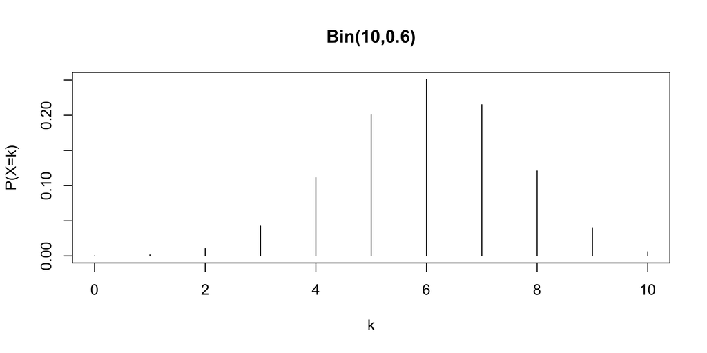

```r
kk <- 0:n
prob <- dbinom(0:n, size = n, prob = p)

plot(kk, prob, type = "h", main = "Bin(10,0.6)", xlab = "k", ylab = "P(X=k)")
```

## Variabile aleatoria normale

Sia $X \sim \text{N}(\mu, \sigma^2)$ una variabile Gaussiana di media $\mu$ e varianza $\sigma^2$, ovvero avente densità

$$f(x) = \frac{1}{\sqrt{2 \pi \sigma^2}}\exp\left\{-\frac{1}{2\sigma^2}(x - \mu)^2\right\}.$$
Se $X \sim (3, 10)$ allora possiamo calcolare il valore di $f(1)$ utilizzando i comandi di **R** nel modo seguente:

```r
x <- 1 # Punto in cui calcolare f(x)
mu <- 3 # Media
sigma2 <- 10 # Varianza


# Calcolo diretto
1 / sqrt(2 * pi * sigma2) * exp(-1 / (2 * sigma2) * (x - mu)^2)
[1] 0.1032883

# Nota: il comando dnorm chiede come input lo scarto quadratico medio, non la varianza
dnorm(x, mean = 3, sd = sqrt(sigma2))
[1] 0.1032883
```

### Funzione di ripartizione e quantili

Sia $X \sim \text{N}(0,1)$ una normale standard. Siamo interessati a calcolare la probabilità dell’evento seguente:

$$\mathbb{P}(|X| \le 1) = \mathbb{P}(-1 \le X \le 1) = \mathbb{P}(X \le 1) - \mathbb{P}(X < -1).$$
Trattandosi di una variabile continua, otteniamo che $\mathbb{P}(X < -1) = \mathbb{P}(X \le -1)$. Pertanto, possiamo calcolare questa probabilità in **R** come segue

```r
pnorm(1) - pnorm(-1)
[1] 0.6826895
```

La continuità della funzione di ripartizione $F(x)$ implica che $\mathcal{Q}(\cdot) = F^{-1}(\cdot)$. Per esempio, il terzo quartile di una distribuzione normale standard, ovvero

```r
qnorm(0.75)
[1] 0.6744898
```

è tale che $F(\mathcal{Q}(0.75)) = F(F^{-1}(0.75))= 0.75$. Infatti:

```r
pnorm(qnorm(0.75))
[1] 0.75
```

### Rappresentazione grafica

Vogliamo ora rappresentare il grafico della densità $f(x)$ di una normale standard nell’intervallo $(-3,3)$. In **R** una qualsiasi funzione può essere rappresentata tramite il comando `curve`.

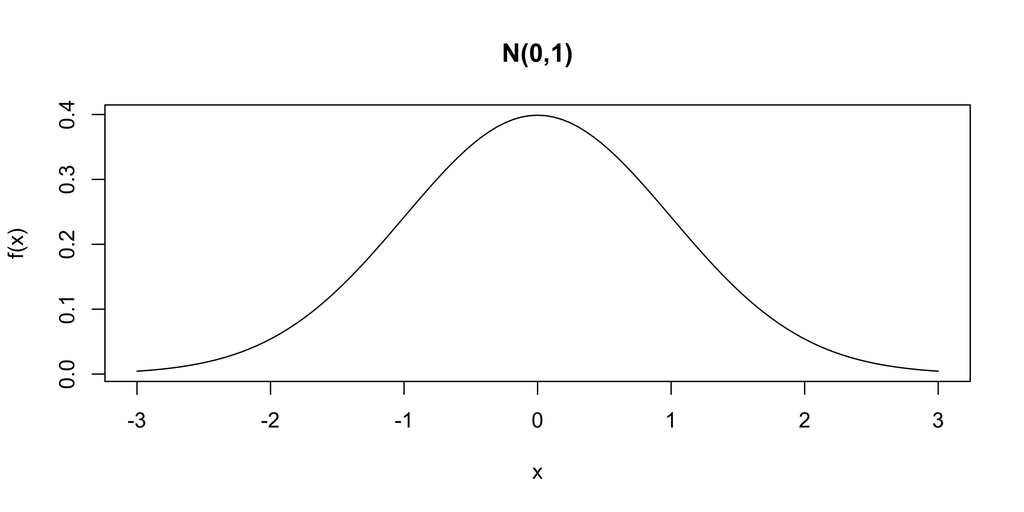

```r
curve(dnorm(x, mean = 0, sd = 1), from = -3, to = 3, ylab = "f(x)", main = "N(0,1)")
```

## Simulazione di valori casuali

La quarta classe di funzioni nella nostra lista è quella del tipo `rdist`, che permette quindi di ottenere un valore “casuale” da una distribuzione.

Per esempio, per campionare $5$ valori indipendenti e identicamente distribuiti (iid) da una normale standard, ovvero

$$X_i \overset{\text{iid}}{\sim} \text{N}(0,1), \qquad i=1,\dots,5$$
possiamo usare in **R** il comando seguente:

```r
R <- 5
rnorm(R, mean = 0, sd = 1)
[1] -0.03165521  0.78198873 -0.90061343 -1.06639356  0.37541903
```

Questo tipo di operazione è enormemente utile per compiere **studi di simulazione**.